# Introdução à Ciência de Dados

Mestrado Profissional em Administração

Prof. Washington Santos da Silva

IFMG - Campus Formiga

5 de junho de 2025

## Diário de Bordo

**O que vimos até aqui?**

- Aula 1 ✅
  - Apresentação da Disciplina ✅
  - Introdução e Contextualização ✅
  - O que é Ciência de Dados? ✅
  - Pesquisa Reproduzível e Ciência de Dados ✅
  - Papéis Profissionais ✅
  - Aplicações ✅
  - Habilidades Interpessoais e Analíticas ✅
  - Apresentação da Disciplina ✅
  - Configurações: Git/GitHub ✅
- Aula 2 ✅
  - Metodologia CRISP-DM ✅
  - Tipos de Análise de Dados ✅
  - Introdução ao RStudio e criação do **seu** Projeto da Disciplina ✅
  - Introdução ao Sistema de Publicação Quarto ✅
  - Introdução ao Git e GitHub: controle de versão e criação do **seu** repositório no GitHub ✅
- Aula 3 ✅
  - Breve Revisão sobre o RStudio ✅
  - Sistema de Publicação Quarto: (Cont.) ✅
  - Introdução ao Git e GitHub: (Cont.) ✅
  - Sessão Prática: Fluxo de trabalho integrando RStudio/Quarto/R/Git/GitHub ✅
- Aula 4 ✅
  - Conceitos de Variáveis e Observações em Estatística ✅
  - Conceito de Dados Organizados (*Tidy Data*) ✅
  - Tipos atômicos e classes principais de dados da linguagem R ✅
  - Tipos de Dados Tradicionais em Finanças: ✅
    - Dados em Secção-Cruzada (ou Transversal) (*Cross-Section Data*) ✅
    - Dados em Secções-Cruzadas Combinadas (*Pooled Cross-Section Data*) ✅
    - Dados em Séries Temporais (*Time Series Data*) ✅
    - Dados em Painel (ou Longitudinais) (*Panel Data*) ✅
  - Importação e Preparação de Dados Típicos de Finanças com exemplos práticos ✅
- Aula 5 ✅
  - Metodologia CRISP-DM: Fases 2 e 3 ✅
  - Revisão sobre Dados Organizados (*Tidy Data*) ✅
  - Introdução ao Pacote tidyr: função pivot_longer() ✅
  - Introdução ao Pacote dplyr: funções select() e filter() ✅
  - Exercícios ✅
- Aula 6 ✅
  - Função mutate ✅
  - Funções group_by e summarize ✅
  - Exercícios ✅
- Aula 7 ✅
  - Introdução ao Pacote dplyr: Tipos Básicos de *joins* ✅
  - Exercícios ✅

## Nesta Aula

**Tópicos - Fundamentos de Probabilidade e Simulação**

- Modelos
- Conceitos Fundamentais de Probabilidade
  - O que é Probabilidade?
  - Probabilidade Condicional e Independência
  - Amostra Aleatória
  - Variáveis Aleatórias e Funções de Probabilidade
  - Função de Distribuição Acumulada
  - Lei dos Grandes Números
- Distribuições de Probabilidade de VA Discretas
  - Distribuição de Bernoulli
  - Características de uma Distribuição de Probabilidade
    - Valor Esperado
    - Variância e Desvio-Padrão
    - Assimetria e Curtose
  - Distribuição Binomial
- Distribuições de Probabilidade de VA Contínuas
  - Teorema Central do Limite
  - Distribuição Normal
- Aplicação
  - Valor-em-Risco (VaR)

**Diretrizes para Aulas Mais Produtivas**

⌨️ **Código com método:**

95% dos erros são evitáveis com:

- Atenção na digitação
- Respeitar a sequência lógica de etapas
- Revisão antes de pedir ajuda

🤝 **Inteligência colaborativa:**

- Compartilhe conhecimento
- Resolva questões técnicas simples com colegas próximos
- Reserve ao professor as dúvidas conceituais complexas

💪 **Capacidade de Resolver Problemas**

Cada erro resolvido é uma evolução da sua habilidade analítica

# Distribuições de Probabilidade de VA Contínuas

## Distribuição Uniforme Contínua

**O que é a Distribuição Uniforme Contínua?**

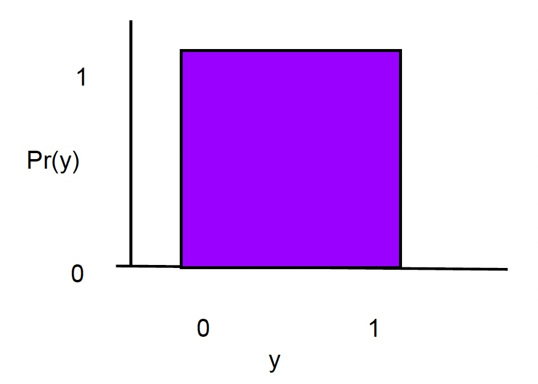

A **distribuição uniforme contínua no intervalo [0, 1]**, denotada $Y \sim U(0,1)$, descreve um fenômeno onde **todos os valores do intervalo** são **igualmente prováveis**.

🔹 Propriedades Fundamentais

- O suporte é o intervalo unitário:

$$Y \in [0, 1]$$

- A fdp é constante:

$$f(y) =
\begin{cases}
1, & \text{se } 0 \leq y \leq 1 \\
0, & \text{caso contrário}
\end{cases}$$

- A área sob a curva é 1 (como toda função densidade de probabilidade):

  $$\int_0^1 f(y) \, dy = 1$$
- Probabilidades são proporcionais ao comprimento do intervalo:

  $$P(Y \in [a, b]) = b - a, \quad \text{para } 0 \leq a < b \leq 1$$

📌 Por que ela é importante?

A distribuição $U(0,1)$ é a base de quase todos os algoritmos de geração de números pseudoaleatórios.

💡 **Ideia central**: geradores de números aleatórios (como `runif()` em R) produzem amostras de $U(0,1)$, e a partir delas é possível gerar amostras de outras distribuições (normal, exponencial, binomial…) por **transformações adequadas**.

💻 Exemplo em R

➤ Gerando 10 números uniformes no intervalo [0,1]:

```r
set.seed(42)  # para reprodutibilidade
runif(10)
```

```
 [1] 0.9148060 0.9370754 0.2861395 0.8304476 0.6417455 0.5190959 0.7365883
 [8] 0.1346666 0.6569923 0.7050648
```

➤ Visualizando a distribuição com um histograma:

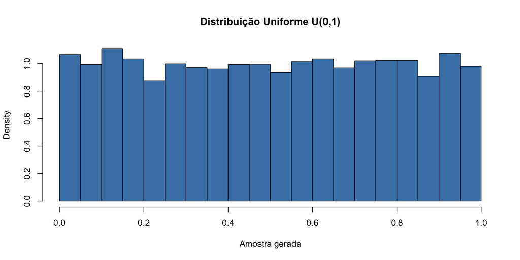

```r
amostra <- runif(10000)
hist(amostra, breaks = 20, col = "steelblue", main = "Distribuição Uniforme U(0,1)",
     xlab = "Amostra gerada", probability = TRUE)
```

➤ Aproximando $P(0.2 < Y < 0.5)$:

```r
mean(amostra > 0.2 & amostra < 0.5)  # Aproximação empírica de P(0.2 < Y < 0.5)
```

```
[1] 0.2901
```

📐 Valor exato: $P(0.2 < Y < 0.5) = 0.5 - 0.2 = 0.3$

Aplicações

- Base para **simulações de Monte Carlo**
- Construção de variáveis aleatórias de qualquer outra distribuição
- Geração de amostras aleatórias na prática

## Transformações da Uniforme

**De $U(0,1)$ para qualquer distribuição**

Se $U \sim U(0,1)$, podemos gerar uma variável aleatória $X$ com distribuição desejada $F_X$ (distribuição acumulada) usando:

$$X = F_X^{-1}(U)$$

Esse método é chamado de **Transformação Inversa da CDF** (ou “inverse transform sampling”).

🔹 Exemplo 1: Gerando variável Exponencial a partir de $U(0,1)$

Queremos gerar uma variável $X \sim \text{Exponencial}(\lambda)$, cuja **função de distribuição acumulada (CDF)** é:

$$F_X(x) = 1 - e^{-\lambda x}, \quad x \geq 0$$

O método da **inversa da CDF** nos diz que podemos gerar amostras de $X$ se:

$$X = F_X^{-1}(U), \quad \text{com } U \sim \mathcal{U}(0,1)$$

📐 Invertendo a CDF:

Começamos com:

$$u = F_X(x) = 1 - e^{-\lambda x}$$

Resolvendo para $x$:

$$e^{-\lambda x} = 1 - u
\Rightarrow -\lambda x = \ln(1 - u)
\Rightarrow x = -\frac{1}{\lambda} \ln(1 - u)$$

🧠 Mas por que usamos $\ln(U)$ em vez de $\ln(1 - U)$?

Como $U \sim U(0,1)$, então também $1 - U \sim U(0,1)$. A distribuição é **simétrica** em torno de 0.5, então qualquer transformação baseada em uma variável uniforme tem a **mesma distribuição** se feita sobre $U$ ou $1 - U$.

💡 Portanto, por **conveniência computacional**, usamos:

$$X = -\frac{1}{\lambda} \ln(U)$$

Esse valor segue a mesma distribuição exponencial.

💻 Em R:

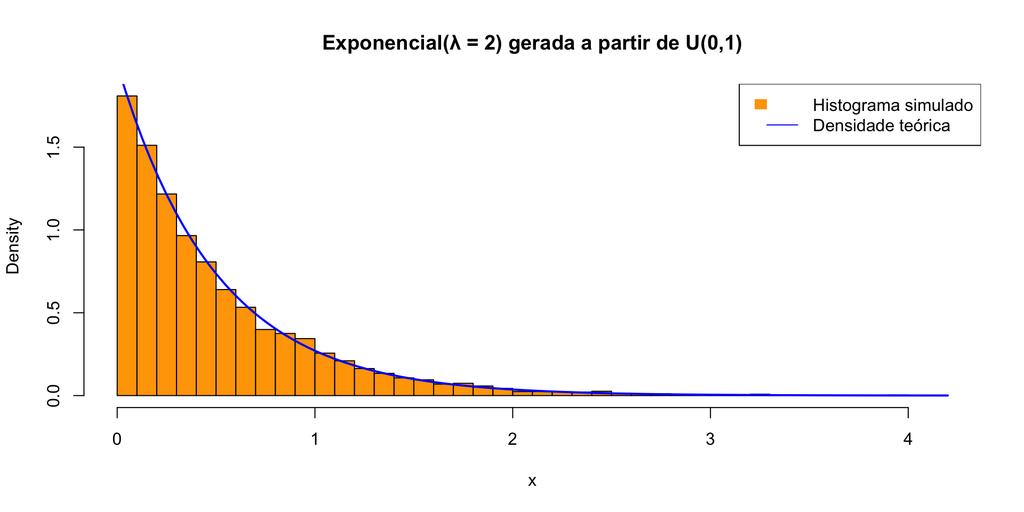

```r
# Gerando 10.000 valores da Exponencial(λ) com λ = 2
set.seed(42)
u <- runif(10000)      # Uniforme(0,1)
lambda <- 2
x <- -log(u) / lambda  # Exponencial(λ)

# Visualizando a distribuição
hist(x, breaks = 30, col = "orange", probability = TRUE,
     main = "Exponencial(λ = 2) gerada a partir de U(0,1)",
     xlab = "x")

# Comparando com densidade teórica
curve(dexp(x, rate = lambda), add = TRUE, col = "blue", lwd = 2)
legend("topright", legend = c("Histograma simulado", "Densidade teórica"),
       fill = c("orange", NA), border = NA, lty = c(NA, 1), col = c(NA, "blue"))
```

✅ Conclusão

- Gerar variáveis **exponenciais** a partir da **uniforme** é um exemplo clássico da **transformação pela inversa da CDF**
- Esse método é uma pedra fundamental dos **geradores de variáveis aleatórias** na prática
- Essa abordagem é **generalizável** para outras distribuições, como log-normal, Weibull e até normal (com outras técnicas)

🔹 Exemplo 2: Geração de Normal Padrão

Não existe inversa analítica simples para a CDF da dist. normal padronizada $\Phi(x)$, mas:

- Pode-se usar aproximações numéricas (função `qnorm()` em R):

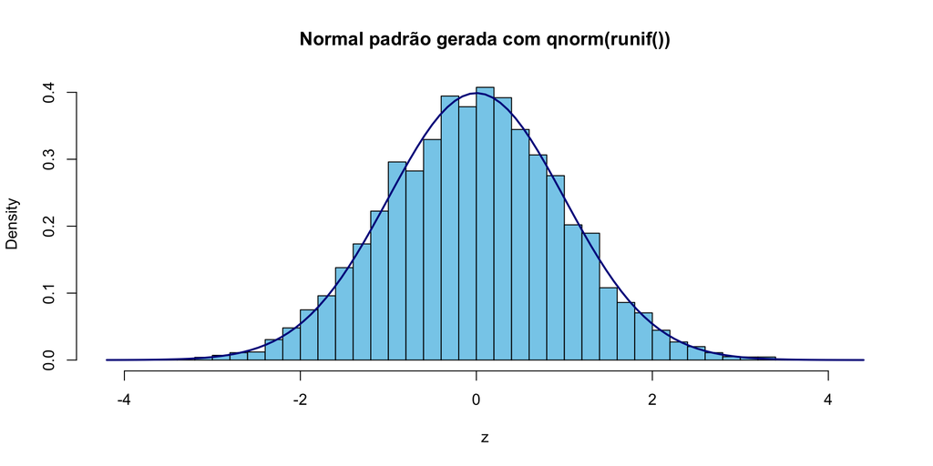

```r
z <- qnorm(runif(10000))  # Z ~ N(0,1)
hist(z, breaks = 30, col = "skyblue", probability = TRUE,
     main = "Normal padrão gerada com qnorm(runif())")
curve(dnorm(x), add = TRUE, col = "darkblue", lwd = 2)
```

🔹 Conclusão

✅ A distribuição $U(0,1)$ serve como *matéria-prima universal* para gerar variáveis aleatórias com qualquer distribuição, via:

- Transformação Inversa (quando possível)
- Métodos numéricos (como `qnorm()`)
- Métodos alternativos: rejeição, Box-Muller, Metropolis-Hastings

## Distribuição Normal - Origem

**Origem da Distribuição Normal**

- A distribuição normal é frequentemente associada ao matemático alemão Carl Friedrich Gauss (1777-1855), que fez contribuições significativas ao estudo da distribuição dos erros de medição em astronomia. Por essa razão, a distribuição normal também é conhecida como “distribuição gaussiana”.
- Gauss utilizou essa distribuição para descrever os erros de medições astronômicas, baseando-se no princípio de que a maioria dos erros seria pequena, enquanto erros grandes seriam raros.
- O termo “normal” foi popularizado posteriormente pelo estatístico britânico Francis Galton (1822-1911). Galton utilizou o termo “normal” para descrever a distribuição de características humanas, como altura e peso, que frequentemente seguem uma forma simétrica em torno de uma média. Ele usou o termo “normal” no sentido de “norma” ou “padrão”, sugerindo que essa distribuição era comum ou típica em muitos fenômenos naturais.
- Embora Gauss tenha trabalhado com a distribuição no contexto de erros de medição, foi o trabalho de Galton e outros que consolidou a ideia de que essa distribuição é “normal” ou típica em muitos contextos, incluindo características biológicas e fenômenos sociais, e assim o termo “distribuição normal” tornou-se amplamente aceito.

## Distribuição Normal

**Importância em Estatística**

- **Modelagem Direta**: Embora muitos processos aleatórios em Administração envolvam variáveis discretas ou condições que não atendem perfeitamente aos requisitos da normalidade (como a **simetria** da distribuição), a distribuição normal ainda pode servir como uma aproximação útil em diversos contextos.
- **Teorema Central do Limite (TCL)**: A importância principal da distribuição normal é **teórica**. O TCL afirma que a soma ou média de um grande número de variáveis aleatórias independentes tende a seguir uma distribuição normal, independentemente da distribuição original, o que fundamenta sua ampla aplicação.
- **Aplicação Prática**: O TCL permite a construção e uso de métodos estatísticos baseados na normalidade, mesmo quando os dados originais não seguem uma distribuição normal.

## Teorema Central do Limite

**Princípios Fundamentais**

- O **Teorema Central do Limite** é uma forte justificativa para sua popularidade:

Seja $X_1,\ldots,X_n$ uma sequência de variáveis aleatórias independentes com distribuição de probabilidade arbitrária com média $\mu_i$ e variância finita $\sigma_{i}^2$. Então:

$$\frac{\bar{X} - \mu}{\sigma/\sqrt{n}} \overset{d}{\to} N(0,1) \,\,(n \rightarrow \infty)$$

## Teorema Central do Limite (TCL)

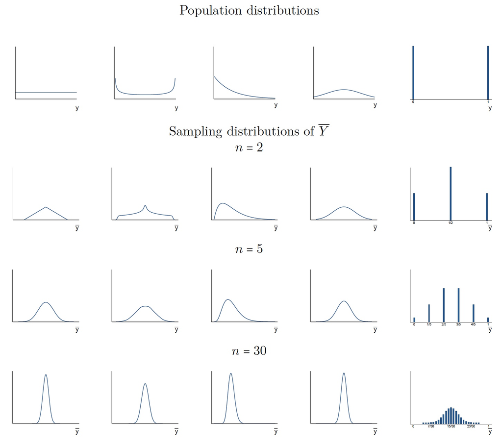

Independente da forma da distribuição da populaçào, na medida que $n$ aumenta, a Distribuição Amostral de $\bar{Y}$ converge para uma distribuição normal

## LGN vs. Teorema Central do Limite

**Qual a diferença entre LGN e TCL?**

Embora ambos envolvam **médias amostrais** de variáveis aleatórias, eles respondem a **perguntas diferentes**.

🔹 Lei dos Grandes Números (LGN)

📌 **Foco**: Convergência da média amostral para o valor esperado.

> “Se repetirmos um experimento muitas vezes, a média observada se aproxima da média verdadeira.”

✏️ Matematicamente:

Se $X_1, \dots, X_n \sim \text{i.i.d.}$ com $\mu = \mathbb{E}[X_i]$, então:

$$\bar{X}_n = \frac{1}{n} \sum_{i=1}^n X_i \xrightarrow[]{n \to \infty} \mu$$

✅ **Resultado determinístico assintótico**: aproximação da **média**.

🔹 Teorema Central do Limite (TCL)

📌 **Foco**: Forma da **distribuição** da média amostral quando $n$ cresce.

> “Mesmo que os dados não sejam normais, a **distribuição da média** amostral se aproxima da normal.”

✏️ Matematicamente:

Se $X_1, \dots, X_n \sim \text{i.i.d.}$ com $\mu$ e $\sigma^2 < \infty$, então:

$$\frac{\bar{X}_n - \mu}{\sigma/\sqrt{n}} \xrightarrow[]{d} \mathcal{N}(0,1)$$

✅ **Resultado probabilístico**: aproximação da **forma da distribuição**.

🧠 Analogia

- **LGN**: Diz que a **média amostral converge** para o **valor esperado** (**média populacional**) quando repetimos o processo aleatório muitas vezes.
- **TCL**: Diz como se comporta a **distribuição* das médias ao longo dessas repetições

💻 Exemplo em R

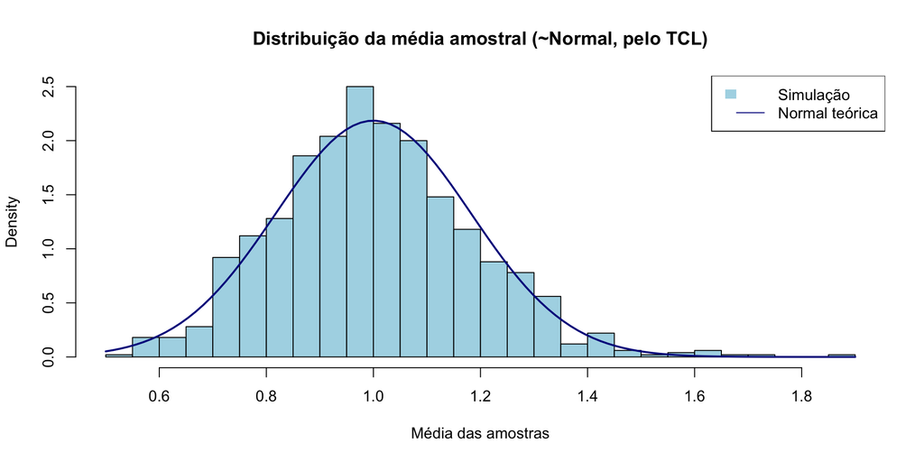

```r
set.seed(42)
media <- numeric(1000)

for (i in 1:1000) {
  amostra <- rexp(30, rate = 1)  # amostras da exponencial (não normal)
  media[i] <- mean(amostra)
}

hist(media, breaks = 30, probability = TRUE,
     main = "Distribuição da média amostral (~Normal, pelo TCL)",
     col = "lightblue", xlab = "Média das amostras")

curve(dnorm(x, mean = 1, sd = 1/sqrt(30)), col = "darkblue", lwd = 2, add = TRUE)
legend("topright", legend = c("Simulação", "Normal teórica"),
       fill = c("lightblue", NA), border = NA, lty = c(NA, 1), col = c(NA, "darkblue"))
```

✅ Resumo

| Conceito | LGN | TCL |
| --- | --- | --- |
| Objetivo | Média converge para valor esperado | Distribuição da média tende à normal |
| Tipo de convergência | Quase certa / em probabilidade | Em distribuição |
| Importância | Estabilidade da média | Inferência e testes estatísticos |

## Distribuição Normal - Função de Probabilidade

**A Distribuição Normal**

**Definição**: Uma variável aleatória (VA) $X$ que segue uma distribuição normal tem sua função de densidade de probabilidade dada por:

$$f(x) = \frac{1}{\sigma \sqrt{2\pi}} e^{-\frac{(x-\mu)^2}{2\sigma^2}}$$

**Características principais:**

- A função é **simétrica** em torno da média $\mu$
- O valor máximo ocorre em $x = \mu$
- A área total sob a curva é igual a 1 (100% de probabilidade)

**Parâmetros (Momentos):**

- **Valor Esperado (Média)**: $E[X] = \mu$
- **Variância**: $V[X] = \sigma^2$
- **Desvio-padrão**: $\sigma$

**Notação**: $X \sim N(\mu, \sigma^2)$

## Função de Densidade Normal

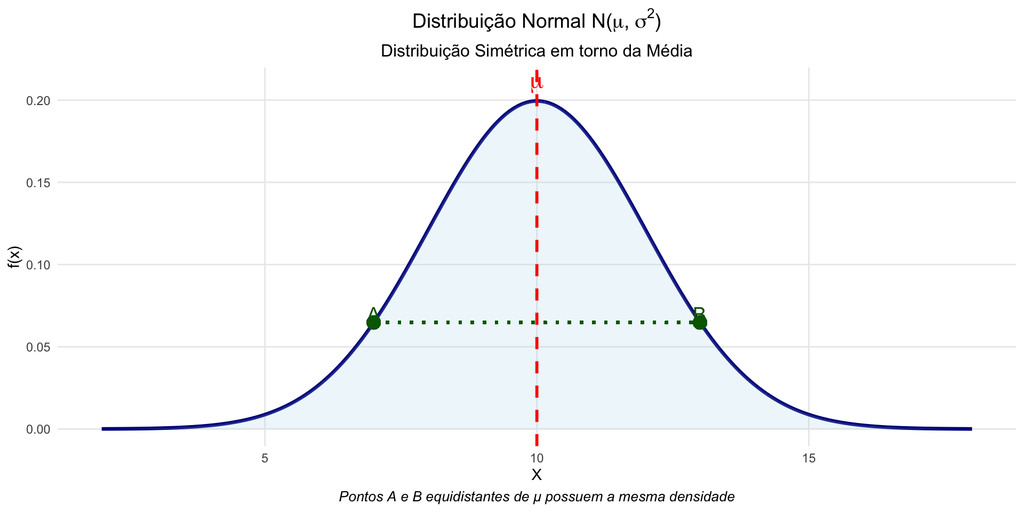

## Distribuição Normal Padronizada

**Padronização: Simplificando os Cálculos**

**Transformação**: Para qualquer $X \sim N(\mu, \sigma^2)$, podemos criar:

$$Z = \frac{X - \mu}{\sigma} \sim N(0, 1)$$

**Função de densidade da Normal Padronizada:**
$$\phi(z) = \frac{1}{\sqrt{2\pi}} e^{-\frac{1}{2}z^2}$$

**Parâmetros:**

- **Média**: $E[Z] = 0$
- **Variância**: $V[Z] = 1$
- **Desvio-padrão**: $\sigma = 1$

**Por que padronizar?**

- Facilita cálculos e comparações
- Permite usar tabelas estatísticas padrão
- Base para o conceito de z-score

## Distribuição Normal Padronizada

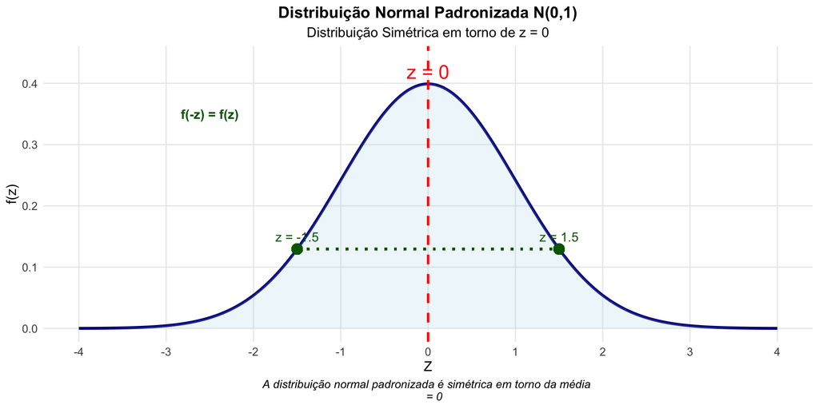

## Distribuição Normal: Efeito da Média

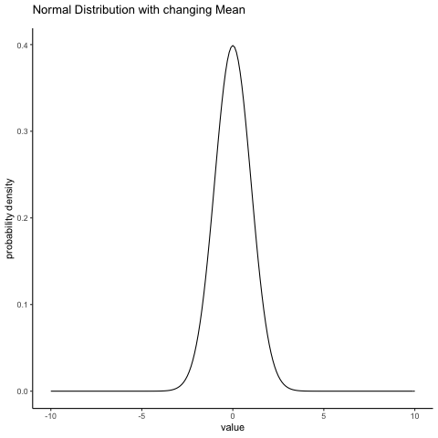

Efeito de Alterar $E[X] = \mu$ (média)

**Observação**

Alterar a média desloca a distribuição horizontalmente sem mudar sua forma

## Distribuição Normal: Efeito da Variância

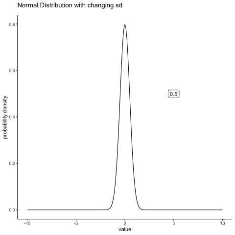

Efeito de alterar $\sigma^2$ (variância)

**Observação**

Maior variância = distribuição mais “dispersa” (maior incerteza)

## Funções R para Distribuição Normal

**Funções para a Distribuição Normal**

| Função | Resultado |
| --- | --- |
| `rnorm(n, mean=0, sd=1)` | Simula n valores |
| `dnorm(x, mean = 0, sd = 1)` | Densidade f(x) no ponto x |
| `pnorm(q, mean = 0, sd = 1, lower.tail = TRUE)` | $P(X \leq q)$ |
| `qnorm(p, mean = 0, sd = 1, lower.tail = TRUE)` | Quantil: $\Phi^{-1}(p)$ |

## Exemplos:

```r
# Simular 5 valores de uma distr. normal padrão
set.seed(123)
rnorm(5)
```

```
[1] -0.56047565 -0.23017749  1.55870831  0.07050839  0.12928774
```

```r
# f(0) - densidade no ponto 0
dnorm(0)
```

```
[1] 0.3989423
```

```r
# P(Z ≤ 1.96)
pnorm(1.96)
```

```
[1] 0.9750021
```

```r
# Encontra z tal que P(Z ≤ z) = 0.975
qnorm(0.975)
```

```
[1] 1.959964
```

# Função rnorm() - Simulação de uma VA com Distribuição Normal

**Simulando $X \sim N(\mu = 3, \sigma = 1)$**

**Objetivo**: Verificar empiricamente as propriedades da distribuição normal

**Procedimento**:

1. Gerar 1000 observações de $X \sim N(3, 1)$
2. Calcular média e desvio-padrão amostrais
3. Visualizar com histograma e densidade empírica

```r
set.seed(123)
x_simulada <- rnorm(1000, mean = 3, sd = 1)
head(x_simulada)
```

```
[1] 2.439524 2.769823 4.558708 3.070508 3.129288 4.715065
```

```r
# Média e desvio padrão amostrais
mean(x_simulada)
```

```
[1] 3.016128
```

```r
sd(x_simulada)
```

```
[1] 0.991695
```

## Visualização dos Dados Simulados

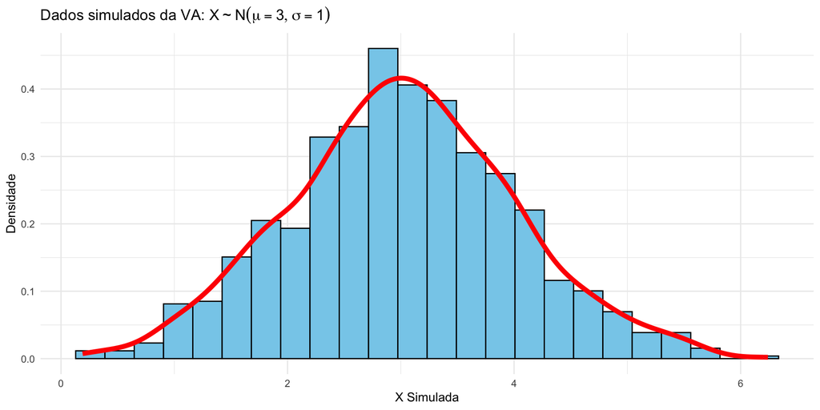

**Lei dos Grandes Números em Ação**

Com 1000 observações, a média amostral (≈3.02) está muito próxima da média teórica (3.0)

## Simulação de uma VA com Distribuição Normal Padronizada

**Simulando $Z \sim N(0, 1)$**

Agora vamos simular a distribuição normal padronizada:

```r
set.seed(123)
z_simulada <- rnorm(1000, mean = 0, sd = 1)
head(z_simulada)
```

```
[1] -0.56047565 -0.23017749  1.55870831  0.07050839  0.12928774  1.71506499
```

```r
# Média e desvio padrão amostrais
mean(z_simulada)
```

```
[1] 0.01612787
```

```r
sd(z_simulada)
```

```
[1] 0.991695
```

## Visualização da Normal Padronizada

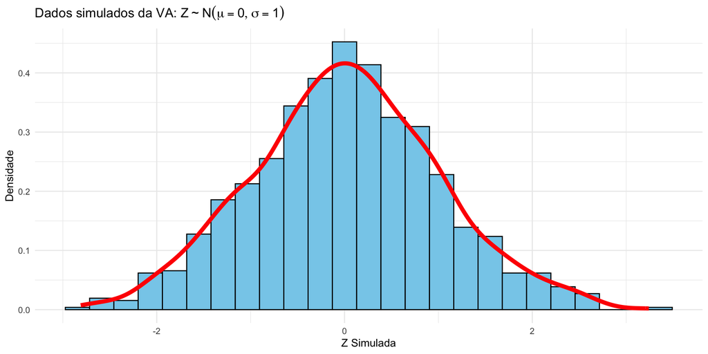

# Função `dnorm(0)` = $f(0) = 0.4$

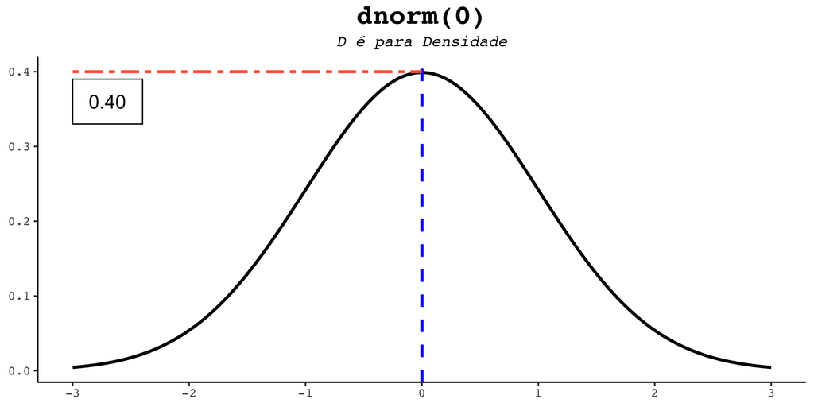

**Interpretação**

dnorm(0) retorna o valor de $f(x)$ no ponto $x = 0$, não uma probabilidade!

## Função pnorm(0) = $P(Z \leq 0) = 0.5$

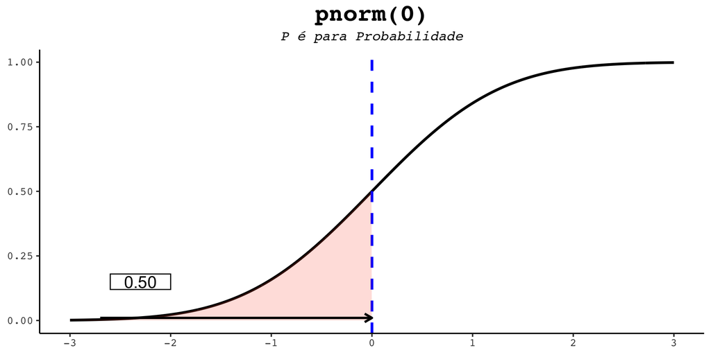

**Interpretação**

pnorm(0) calcula: “Qual a probabilidade de Z ser menor ou igual a 0?”

## pnorm(1) = $P(Z \leq 1) = 0.84$

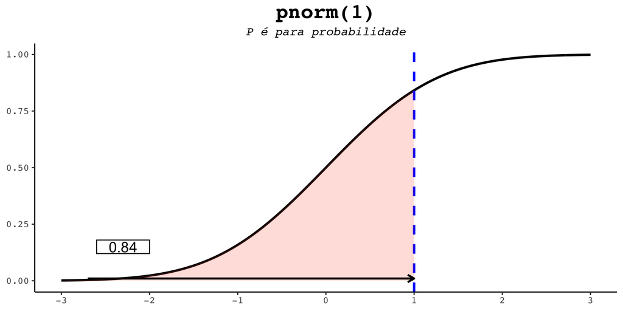

**Interpretação**

pnorm(1) responde: “Qual a probabilidade de Z ser menor ou igual a 1?”

## 1 - pnorm(0) = $P(Z > 0) = 0.5$

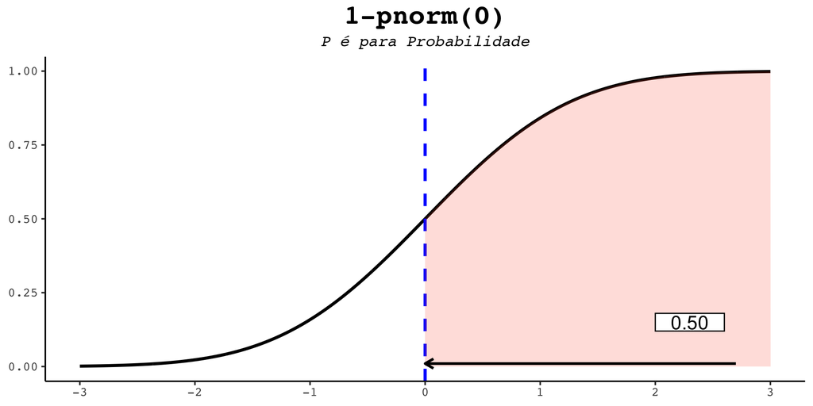

**Interpretação**

1 - pnorm(0) responde: “Qual a probabilidade de Z ser maior que 0?”

## Caso Comum: Probabilidade entre Dois Valores

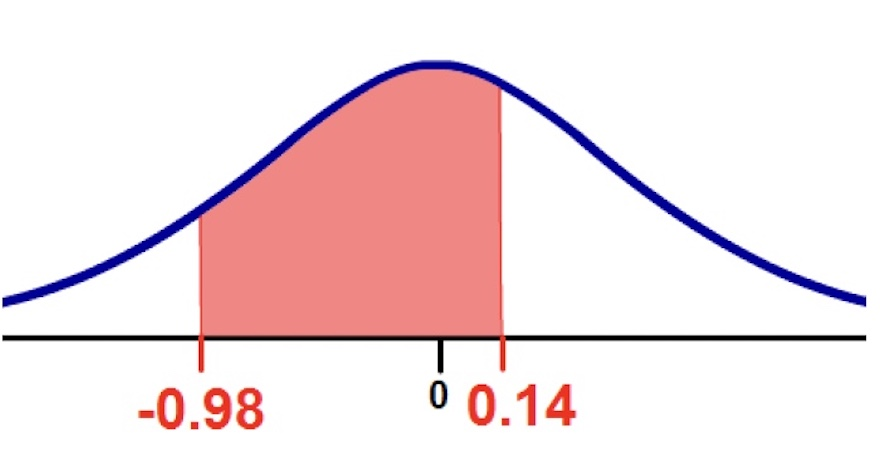

$$\begin{align}
P(-0.98 \leq Z \leq 0.14) &= P(Z \leq 0.14) - P(Z \leq -0.98) \\
&= F(0.14) - F(-0.98) \\
& = \text{pnorm}(0.14) - \text{pnorm}(-0.98) \\
& = 0.5557 - 0.1635 \\
& = 0.3922
\end{align}$$

**Explicação**

A probabilidade de Z estar entre -0.98 e 0.14 é a diferença entre as probabilidades acumuladas até esses pontos.

## Função qnorm(0.5) = $\Phi^{-1}(0.5) = 0$

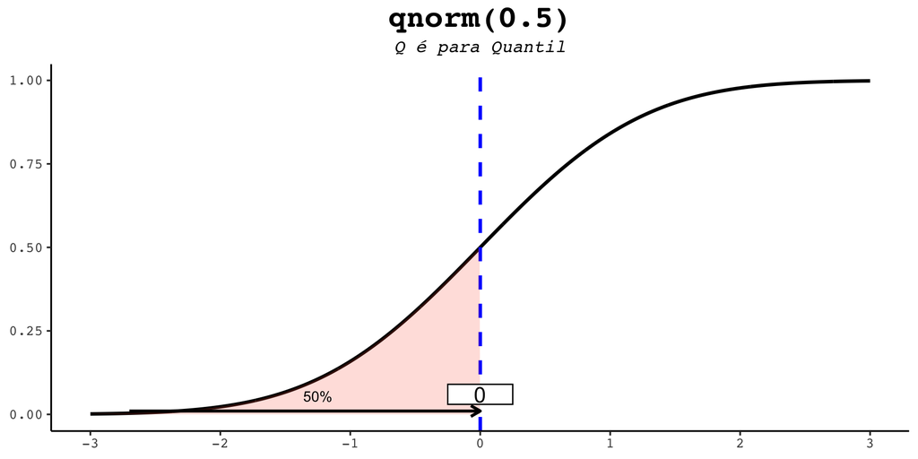

**Interpretação**

qnorm(0.5) calcula: “Qual quantil $Z$ deixa 50% da distribuição à sua esquerda?” Ou seja, $P(Z \leq q) = 0.5$.

## qnorm(0.9) = $\Phi^{-1}(0.9) = 1.28$

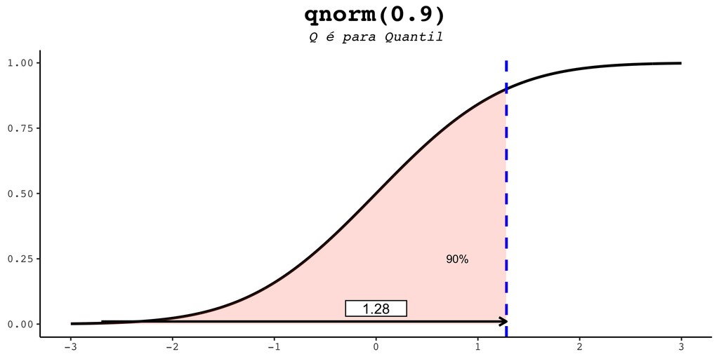

**Interpretação**

qnorm(0.9) calcula: “Qual valor $Z$ deixa 90% da probabilidade à sua esquerda?”

## Exercício 1

**Calcule as seguintes probabilidades associadas a uma distribuição normal padronizada.**

1. $P(Z <= 1.25)$
2. $P(Z > 1.25)$
3. $P(Z <= - .25)$
4. $P(-0.8 <= Z <= 1..25)$

## Exercício 2

**Distribuicao Normal: Calcule os quantis associados às seguintes probabilidades**

1. $P(Z < q)$ = 0.9798
2. $P(Z < q)$ = 0.2546
3. $P(Z > q)$ = 0.1075
4. $P(Z > q)$ = 0.9418

# Simulação de Monte Carlo

## Métodos de Monte Carlo

**O que são Métodos de Monte Carlo?**

- Em termos gerais, métodos de Monte Carlo consistem em resolver problemas numéricos usando simulações baseadas em amostragem aleatória — isto é, com auxílio de números (pseudo-)aleatórios.
- São úteis especialmente quando o problema é de alta complexidade ou dimensionalidade, tornando inviável uma solução analítica ou mesmo métodos numéricos determinísticos convencionais.
- Eles permitem estudar o comportamento médio de sistemas aleatórios ou aproximar integrais, probabilidades e soluções de equações diferenciais, por meio de repetições estocásticas.
- O nome foi cunhado na década de 1940 por Stanislaw Ulam e John von Neumann, inspirado nos jogos de azar do Cassino de Monte Carlo, enquanto trabalhavam no Projeto Manhattan.
- **Por que o Método de Monte Carlo funciona?**
- A ideia fundamental por trás do método é a **Lei dos Grandes Números (LGN)**: dada uma sequência de variáveis aleatórias independentes e identicamente distribuídas, a média amostral converge (quase certamente) para o valor esperado da distribuição.
- Suponha que estamos interessados em estimar a probabilidade de um evento $A$. Podemos definir uma variável aleatória indicadora para cada repetição:

$$X_k =
\begin{cases}
1, & \text{se o evento } A \text{ ocorre na } k\text{-ésima simulação} \\
0, & \text{caso contrário}
\end{cases}$$

- A média das $n$ simulações:

$$\hat{P}_n = \frac{1}{n} \sum_{k=1}^{n} X_k$$

é um estimador não-viesado de $P(A)$, pois $\mathbb{E}[X_k] = P(A)$ para cada $k$. Pela **Lei dos Grandes Números**, temos:

$$\hat{P}_n \xrightarrow[]{n \to \infty} P(A)$$

com alta probabilidade (ou quase certamente, dependendo da versão da LGN usada).

**Etapas de uma Simulação de Monte Carlo**

1. **Modelagem**: Modelar o “experimento” aleatório no computador com o uso de variáveis pseudo-aleatórias.
2. **Critério de Sucesso**: Determinar se o evento de interesse $A$ ocorreu em cada simulação.
3. **Repetição**: Repetir esse processo $n$ vezes e calcular a proporção (média) dos “sucessos” e assim estimar a probabilidade.

**Exemplo 1:** Probabilidade de obter “cara” em lançamentos de uma moeda honesta

Vamos simular $n$ lançamentos e estimar $P(\text{cara})$:

```r
mean(sample(0:1, 10, replace = TRUE)) # 10 lançamentos
```

```
[1] 0.3
```

```r
mean(sample(0:1, 100, replace = TRUE)) # 100 lançamentos
```

```
[1] 0.51
```

```r
mean(sample(0:1, 1000, replace = TRUE)) # 1000 lançamentos
```

```
[1] 0.476
```

```r
mean(sample(0:1, 10000, replace = TRUE)) # 10000 lançamentos
```

```
[1] 0.4975
```

- `0` representa “coroa” e `1` representa “cara”.
- A função `mean()` fornece a proporção de caras, que é uma estimativa de $P(\text{cara}) = 0.5$.

**Exemplo 2** Probabilidade de obter três “caras” em três lançamentos

```r
n <- 10000
vetor_simulacoes <- numeric(n)

for (i in 1:n) {
  teste <- sample(0:1, 3, replace = TRUE)
  vetor_simulacoes[i] <- as.numeric(sum(teste) == 3)
}

mean(vetor_simulacoes)
```

```
[1] 0.1272
```

- Cada iteração simula 3 lançamentos.
- Se todos os 3 forem “cara”, soma será 3, registrando um “sucesso”.
- A média final é a estimativa de $P(\text{3 caras}) = \frac{1}{8} = 0,125$.

**Conclusão**

Métodos de Monte Carlo baseiam-se na ideia de que, ao repetir um experimento aleatório muitas vezes, a média dos resultados converge para o valor esperado do fenômeno modelado — uma consequência direta da **Lei dos Grandes Números**. Isso os torna ferramentas poderosas para resolver problemas onde abordagens determinísticas são impraticáveis.

## Integração de Monte Carlo

**O que é Integração de Monte Carlo?**

Considere a integral definida de uma função real e limitada $f$:

$$I = \int_{a}^{b} f(x) \, dx$$

Essa integral pode ser interpretada como o valor esperado de $f$ sob uma variável aleatória $U \sim U(a, b)$, isto é, uma distribuição uniforme no intervalo $[a, b]$.

Sabemos que:

$$E[f(U)] = \int_{a}^{b} f(x) \cdot \frac{1}{b - a} \, dx$$

Multiplicando ambos os lados por $(b - a)$, obtemos:

$$\int_{a}^{b} f(x) \, dx = (b - a) \cdot E[f(U)]$$

Essa igualdade fornece a base teórica para a **integração via Monte Carlo**.

**Como funciona?**

Se $U_1, \dots, U_N \sim U(a, b)$ forem amostras independentes e identicamente distribuídas (i.i.d), então:

$$\hat{I}_N = \frac{b - a}{N} \sum_{i=1}^{N} f(U_i)$$

é um estimador não-viesado da integral ( I ), e pela **Lei dos Grandes Números**:

$$\hat{I}_N \xrightarrow[]{n \to \infty} \int_a^b f(x) dx$$

**Caso particular: Intervalo** $[0, 1]$

Quando $a = 0$ e $b = 1$, o fator $(b - a) = 1$, e temos:

$$\int_{0}^{1} f(x) dx = E[f(U)], \quad \text{com } U \sim U(0,1)$$

Estimamos a integral com:

$$\hat{I}_N = \frac{1}{N} \sum_{i=1}^{N} f(U_i)$$

**Exemplo 1**

Para resolver a seguinte integral definida via simulação de Monte Carlo:

$$\int_{2}^{5} \sin(x)dx$$

basta fazermos:

```r
# fixando a semente do algoritmo
set.seed(2023)

# integracao via SMC

## Gerando amostras uniformes no intervalo [2, 5]
u <- runif(100000, min = 2, max = 5)

## Calculando a média/valor esperado da função seno
(5 - 2)*mean(sin(u))
```

```
[1] -0.6999126
```

Resolvendo analiticamente a integral, verifica-se que o valor exato é -0,7.

```r
# resolvendo numericamente a integral
integrate(sin, 2, 5)
```

```
-0.699809 with absolute error < 2.1e-14
```

**Exemplo 2:**

Considere a integral:

$$\int_{0}^{1} \frac{\sin(x(1 - x))}{1 + x + \sqrt{x}} \, dx$$

Esta integral pode ser estimada por Monte Carlo amostrando $U_i \sim \mathcal{U}(0,1)$ e calculando a média:

```r
# Semente para reprodutibilidade
set.seed(2023)

# Função de interesse
f <- function(x) sin(x*(1 - x)) / (1 + x + sqrt(x))

# Integração via Monte Carlo
u <- runif(100000)
mean(f(u))  # Estimativa da integral
```

```
[1] 0.07867095
```

Podemos comparar com o valor exato (numérico) da integral usando o método adaptativo de quadratura:

```r
integrate(f, 0, 1)
```

```
0.07852747 with absolute error < 9.2e-06
```

**Conclusão**

- A **integração de Monte Carlo** transforma um problema determinístico (uma integral) em um problema probabilístico (cálculo de um valor esperado).
- Os **limites de integração** determinam o intervalo da distribuição uniforme usada para gerar amostras.
- A precisão aumenta com o número de amostras, graças à **Lei dos Grandes Números**.

## Exercício 3

**Simulação versus Cálculo Exato**

Simule 1.000 realizações de uma variável aleatória ($Z$) que segue uma distribuição normal padronizada ($Z \sim N(\mu = 0, \sigma = 1)$) e use sua amostra simulada para estimar as seguintes probabilidades:

1. $P(Z > 2.5)$
2. $P(-1.2 < Z < 1.3)$

Compare os dois resultados com o valor exato que pode ser obtido com a função `pnorm()`.

## Exercício 4

**Resolvendo Integrais por Simulação de Monte Carlo**

Use Simulação de Monte Carlo para estimar as seguintes integrais utilizando 1000 repetições. Compare com a resposta exata, a qual pode ser obtida com a função `integrate()` da linguagem R.

1. $\int_{1}^{3} x^2dx$.
2. $\int_{0}^{\pi} sin(x)dx$

# Distribuição Conjunta de Variáveis Aleatórias

## Distribuição Conjunta de Variáveis Aleatórias

**O que é uma Distribuição Conjunta?**

Uma **distribuição conjunta** descreve a probabilidade de diferentes combinações de valores para duas variáveis aleatórias $X$ e $Y$:

- **Discreta**: $f(x, y) = P(X = x \cap Y = y)$
- **Contínua**: $f(x, y)$ é uma densidade tal que
  $$\iint f(x, y)\,dx\,dy = 1$$

Propriedades:

- $f(x, y) \geq 0$ para todo $(x, y)$
- $\sum_x \sum_y f(x, y) = 1$ (no caso discreto)
- **Distribuições Marginais**

As distribuições **marginais** mostram o comportamento de **uma única variável**.

São obtidas a partir da distribuição conjunta somando (ou integrando) sobre a outra variável:

- Para $X$:

  $$f_1(x) = \sum_y f(x, y) \quad \text{ou} \quad f_1(x) = \int f(x, y)\,dy$$
- Para $Y$:

  $$f_2(y) = \sum_x f(x, y) \quad \text{ou} \quad f_2(y) = \int f(x, y)\,dx$$

**Analogia**

Pense em uma **planilha eletrônica** com:

- Linhas = valores de $X$ (ex: *renda*)
- Colunas = valores de $Y$ (ex: *felicidade*)
- Cada célula = probabilidade $P(X = x, Y = y)$

👉 A **distribuição marginal de $X$** é obtida somando as células **linha por linha**.

👉 A **marginal de $Y$**, somando **coluna por coluna**.

Assim como na planilha, você pode ver o total de uma linha sem olhar os detalhes da coluna — isso é uma **marginal**.

## Distribuição Condicional

**Descrição**

A **distribuição condicional** de $Y$ dado $X = x$ é:

$$f(y \mid x) = \frac{f(x, y)}{f_1(x)} \quad \text{(se } f_1(x) > 0\text{)}$$

Ela representa a probabilidade de $Y = y$ **dado que (ou condicional a)** $X = x$.

## Exemplo: Tabela de Distribuição Conjunta

**Renda vs. Felicidade**

Tabela de contingência (distribuição conjunta empírica) entre **faixa de renda** e **felicidade**:

| Felicidade \ Renda | Baixa | Média | Alta | Total |
| --- | --- | --- | --- | --- |
| Pouca | 20 | 10 | 5 | 35 |
| Moderada | 30 | 40 | 25 | 95 |
| Muita | 10 | 30 | 30 | 70 |
| **Total** | 60 | 80 | 60 | 200 |

Podemos obter:

- **Distribuição conjunta**: $P(X = \text{Média} \cap Y = \text{Muita}) = \frac{30}{200} = 0.15$
- **Marginais**: $P(X = \text{Alta}) = \frac{60}{200} = 0.30$
- **Condicional**: $P(Y = \text{Muita} \mid X = \text{Alta}) = \frac{30}{60} = 0.50$
- **Analogia Intuitiva**

Esta tabela é como uma **planilha populacional**:

- Cada célula mostra quantas pessoas estão em uma combinação de renda e felicidade.
- A soma das células mostra o todo (200 pessoas).

Se fixarmos uma **coluna** (ex: “Alta Renda”), estamos **condicionando**.

Se as proporções da felicidade forem semelhantes em todas as rendas, podemos suspeitar de **independência**.

## Independência

**Independência de Variáveis Aleatórias**

$X$ e $Y$ são **independentes** se:

$$f(x, y) = f_1(x) \cdot f_2(y)$$

ou seja:

$$f(y \mid x) = f_2(y), \quad \text{e} \quad f(x \mid y) = f_1(x)$$

Nesse caso, saber o valor de uma variável **não altera** a distribuição da outra.

- **Analogia**

Se $X$ = “renda” e $Y$ = “felicidade”, independência significa que **conhecer a renda de alguém não diz nada sobre sua felicidade**, e vice-versa.

## Correlação entre Variáveis Aleatórias

**Correlação**

- Quando as variáveis aleatórias $X$ e $Y$ **não são independentes**, certos valores de $X$ tendem a estar associados a certos valores de $Y$. Ou seja, existe uma **relação ou associação** entre elas.
- Ao amostrarmos aleatoriamente pares $(X, Y)$ de sua **distribuição conjunta de probabilidade**, com médias marginais $\mu_X$ e $\mu_Y$, dizemos que há uma **associação positiva** se, em média, o valor de $(X - \mu_X)(Y - \mu_Y)$ é positivo.

Em outras palavras:

- Quando $X > \mu_X$, geralmente também temos $Y > \mu_Y$;
- Quando $X < \mu_X$, geralmente também temos $Y < \mu_Y$.

Já uma **associação negativa** ocorre se, em média, o produto $(X - \mu_X)(Y - \mu_Y)$ assume valores negativos — isto é, quando $X$ está acima da média ($X > \mu_X$), tende-se a observar $Y < \mu_Y$, e vice-versa.

## Covariância e Correlação

**Covariância**

A **covariância** entre duas variáveis aleatórias $X$ e $Y$ tendo $E(X) = \mu_X$ e $E(Y) = \mu_Y$ é definida como:

$$\text{Cov}(X, Y) = E[(X - \mu_X)(Y - \mu_Y)] = E(XY) - E(X)E(Y)$$

Propriedades:

- **Simétrica**: $\text{Cov}(X, Y) = \text{Cov}(Y, X)$
- $\text{Cov}(X, Y) > 0$: variáveis tendem a cresce/decrescer juntas
- $\text{Cov}(X, Y) < 0$: uma cresce, a outra decresce, e vice-versa.
- Tem unidade: $\text{unid}(X) \cdot \text{unid}(Y)$

A covariância é como a **média dos produtos de desvios conjuntos**.

## Correlação entre Variáveis Aleatórias

**Definição Correlação**

A correlação entre uma variável aleatória $X$, tendo $E(X) = \mu_X$ e desvio padrão $\sigma_X$, e uma variável aleatória $Y$, tendo $E(Y) = \mu_Y$ e desvio padrão $\sigma_Y$, é definida como:

$$\text{Cor}(X, Y) =
E\left[ \left( \frac{X - \mu_X}{\sigma_X} \right)\left( \frac{Y - \mu_Y}{\sigma_Y} \right) \right] = \frac{\text{Cov}(X, Y)}{\sigma_X \sigma_Y}$$

A **correlação** padroniza a covariância, removendo as unidades e está confinada ao intervalo $[-1, 1]$, podendo fornecer uma medida da força da **relação linear** entre $X$ e $Y$.

É como comparar os **desvios padronizados**: ambos estão acima da média? quanto?

## Correlação entre Variáveis Aleatórias

**Padrões Identificáveis em Gráficos de Dispersão**

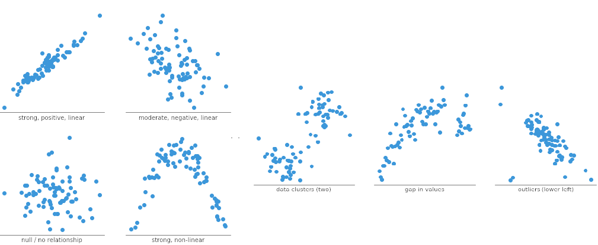

## Variância da Soma de Variáveis Aleatórias

**Fórmula da Variância da Soma**

Sejam $X$ e $Y$ variáveis aleatórias com variâncias finitas:

$$Var(X + Y) = Var(X) + Var(Y) + 2Cov(X, Y)$$

**Demonstração**

Por definição $V(X) = E(X - E(X))^2$, portanto:

$$Var(X + Y) = E\left[(X + Y) - E(X + Y))^2 \right]$$

Sabemos que:

$$E(X + Y) = E(X) + E(Y)$$

Logo:

$$\begin{aligned}
((X + Y) - E(X + Y))^2
&= (X - E(X) + Y - E(Y))^2 \\
&= (X - E(X))^2 + (Y - E(Y))^2 + 2(X - E(X))(Y - E(Y))
\end{aligned}$$

Tomando o valor esperado:

$$\begin{aligned}
Var(X + Y)
&= E[(X - E(X))^2] + E[(Y - E(Y))^2] + 2E[(X - E(X))(Y - E(Y))] \\
&= Var(X) + Var(Y) + 2Cov(X, Y)
\end{aligned}$$

- **Versão com Correlação**

Se $X$ e $Y$ têm desvios padrão $\sigma_X$ e $\sigma_Y$, e correlação $\rho_{XY}$:

$$Var(X + Y) = \sigma_X^2 + \sigma_Y^2 + 2\,\rho_{XY} \sigma_X \sigma_Y$$

## Independência Implica Correlação Zero

**Demonstração**

Se $X$ e $Y$ são independentes, então sua densidade conjunta fatoriza:

$$f(x, y) = f_1(x) f_2(y)$$

Então:

$$E(XY) = \iint xy f(x, y) \, dx \, dy
= \left( \int x f_1(x)\, dx \right) \left( \int y f_2(y)\, dy \right)
= E(X) E(Y)$$

Portanto:

$$\text{cov}(X, Y) = E(XY) - E(X)E(Y) = 0$$

Logo:

$$\text{corr}(X, Y) = \frac{\text{cov}(X, Y)}{\sigma_X \sigma_Y} = 0$$

- **Mas o Inverso Não é Verdadeiro**

## Correlação Zero Não Implica Independência

**Por que Correlação Zero Não Garante Independência?**

A **correlação** entre $X$ e $Y$ mede a associação **linear** entre elas:

$$\rho_{XY} = \frac{E[(X - \mu_X)(Y - \mu_Y)]}{\sigma_X \sigma_Y}$$

Se $\rho_{XY} = 0$, então **não há relação linear** entre $X$ e $Y$.  
Mas isso **não exclui** a possibilidade de **dependência não linear**.

- **Independência é Mais Forte**

$X$ e $Y$ são **independentes** quando:

$$f(x, y) = f_1(x) \cdot f_2(y) \quad \text{para todo } x, y$$

Ou seja, **qualquer conhecimento sobre $X$ não altera a distribuição de $Y$** e vice-versa:

$$P(Y \mid X) = P(Y)$$

Essa condição elimina **toda forma de dependência**, linear ou não.

- **Exemplo Clássico**

Seja $X \sim U(-1, 1)$ e $Y = X^2$

- $\rho_{XY} = 0$
- Mas $Y$ é função determinística de $X$ ⟹ Dependência total, correlação nula**

Esse é um caso de **dependência não linear invisível à correlação**.

# Aplicação - Valor-em-Risco (VaR)

## Valor-em-Risco (VaR)

**O que é o Valor-em-Risco?**

O **Valor-em-Risco (VaR)** (*Value_at_Risk*) é uma medida de risco baseada em **quantis**, que estima a **perda máxima esperada** de um investimento, **em um horizonte temporal fixado**, com **um nível de confiança predefinido**.

- **Definição informal**: “O VaR é o quanto se pode perder em condições normais, com certa confiança.”
- **Definição formal**: O $\text{VaR}_\alpha$ é o quantil $\alpha$ da distribuição da variável aleatória $R$ (retorno), tal que:

$$P(R \leq \text{VaR}_\alpha) = \alpha$$

**Exemplo**: Um VaR de 5% de R$ 3.000 significa que há 5% de chance de uma perda **superior a R$ 3.000** em um dia.

**Aplicações**:

- Exigências regulatórias (Basileia)
- Gestão de risco financeiro
- Comunicação de risco a investidores

## Cálculo Paramétrico do VaR

**VaR com Retornos Normais**

Assumindo que os retornos $R$ de um ativo seguem uma distribuição normal:

$$R \sim \mathcal{N}(\mu, \sigma^2)$$

Padronizando:

$$P(R \leq \text{VaR}_\alpha) = \alpha \Rightarrow \frac{\text{VaR}_\alpha - \mu}{\sigma} = z_\alpha$$

Isolando o VaR:

$$\boxed{ \text{VaR}_\alpha = \mu + z_\alpha \cdot \sigma }$$

- $\mu$ = retorno esperado
- $\sigma$ = desvio padrão (volatilidade)
- $z_\alpha$ = quantil da normal padrão para nível $\alpha$

**Nota**: Alguns autores escrevem $\mu - z_{1 - \alpha} \cdot \sigma$; ambos são equivalentes desde que o valor de $z$ represente a cauda esquerda.

## Exemplo Prático: Cálculo de VaR

**Cenário: Investimento em Ações**

**Dados históricos de um fundo de ações:**

- Retorno médio mensal: 1.2%
- Volatilidade mensal: 4.5%
- Valor investido: R$ 100.000

**Pergunta**: Qual o VaR mensal de 95%?

**Solução**:

$$\text{VaR}_{95\%} = 1.2\% + (-1.645) \times 4.5\%$$

$$\text{VaR}_{95\%} = 1.2\% - 7.4\% = -6.2\%$$

**Em valores monetários**:

$$\text{VaR}_{95\%} = R\$ 100.000 \times (-6.2\%) = -R\$ 6.200$$

**Interpretação**: Existe apenas 5% de chance de a perda mensal exceder R$ 6.200.

## Implementação do VaR em R

```r
# Parâmetros do investimento
retorno_medio <- 0.012      # 1.2% ao mês
volatilidade <- 0.045       # 4.5% ao mês
valor_investido <- 100000   # R$ 100.000

# Cálculo do VaR 95%
nivel_confianca <- 0.95
quantil_95 <- qnorm(1 - nivel_confianca)  # -1.645
quantil_95
```

```
[1] -1.644854
```

```r
# Cálculo do VaR 95% percentual
var_percentual_95 <- retorno_medio + quantil_95 * volatilidade
var_percentual_95
```

```
[1] -0.06201841
```

```r
# Cálculo do VaR 95% monetário
var_monetario_95 <- valor_investido * var_percentual_95
var_monetario_95
```

```
[1] -6201.841
```

```r
# Cálculo do VaR 99%
quantil_99 <- qnorm(1 - 0.99)  # -2.326

# Cálculo do VaR 99% percentual
var_percentual_99 <- retorno_medio + quantil_99 * volatilidade
var_percentual_99
```

```
[1] -0.09268565
```

```r
# Cálculo do VaR 99% monetário
var_monetario_99 <- valor_investido * var_percentual_99
var_monetario_99
```

```
[1] -9268.565
```

## Visualização do VaR

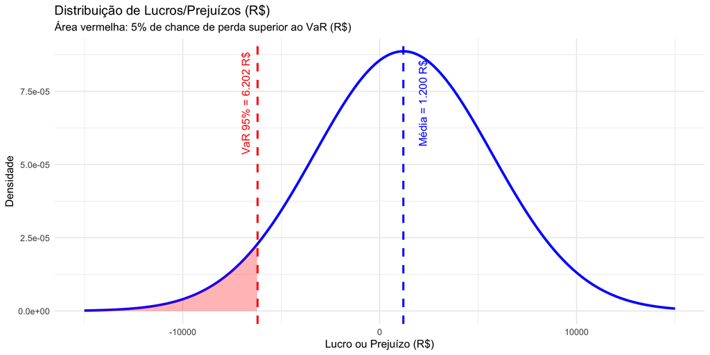

## Exercício 5

**Cálculo do VaR**

Você está analisando um portfólio de títulos governamentais com:

- Retorno médio mensal: 0.8%
- Volatilidade mensal: 3.2%
- Valor investido: US$ 250.000

Considerando que os retornos do protfólio seguem aproximadamente uma distribuição normal:

- Calcule o VaR mensal de 95% (percentual e monetário)
- Calcule o VaR mensal de 99% (percentual e monetário)
- Compare os resultados e interprete a diferença

**Dica**: Use `qnorm()` no R para obter os quantis da distribuição normal

## Exercício 5

**Interpretação do VaR**

Você está analisando um portfólio de títulos governamentais com:

- Retorno médio mensal: 0.8%
- Volatilidade mensal: 3.2%
- Valor investido: US$ 250.000

Considerando que os retornos do protfólio seguem aproximadamente uma distribuição normal:

- Calcule o VaR mensal de 95% (percentual e monetário)
- Calcule o VaR mensal de 99% (percentual e monetário)
- Compare os resultados e interprete a diferença

**Dica**: Use `qnorm()` no R para obter os quantis da distribuição normal

## Atualizando os Repositórios

**Instruções**

1. No terminal do RStudio, verifique quais arquivos/pastas foram modificados ou criados com:

```bash
git status
```

2. Você pode adicionar todos os arquivos de uma vez com:

```bash
git add .
```

3. Execute git status novamente para confirmar que todos os arquivos foram adicionados (aparecerão em verde sob “*Changes to be committed*”):

```bash
git status
```

4. Se tudo estiver em verde, faça um commit com uma mensagem descritiva:

```bash
git commit -m "atualizacoes aula 9"
```

5. Se algum arquivo ou pasta ainda aparecer em vermelho após o segundo git status, adicione as pastas/arquivos um por um:

```bash
git add relatorios/07-relatorio/07-relatorio.qmd
```

6. Execute git status novamente e faça o commit quando todos os arquivos estiverem em verde:

```bash
git commit -m "atualizacoes aula 9"
```

7. Envie o repositório local atualizado para o GitHub:

```bash
git push origin main
```